# TIGPS2023主要照顧者問卷成果報告

### 子女學業預期_若無限制下 (樣本數=4247)

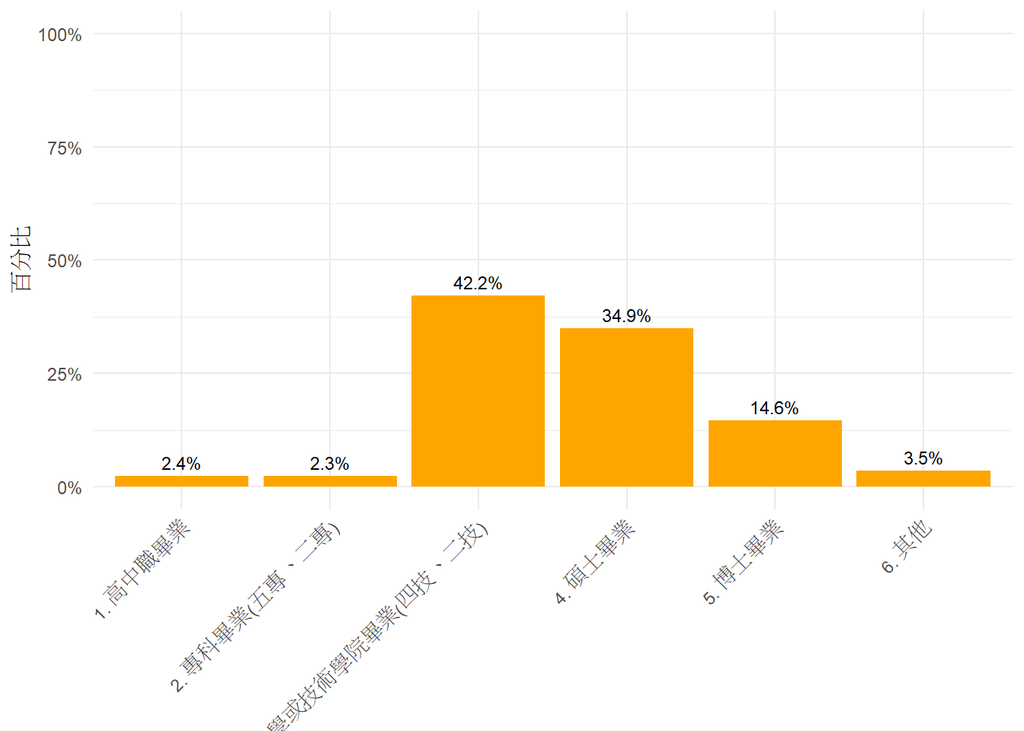

### 子女學業預期_考量子女能力下 (樣本數=4250)

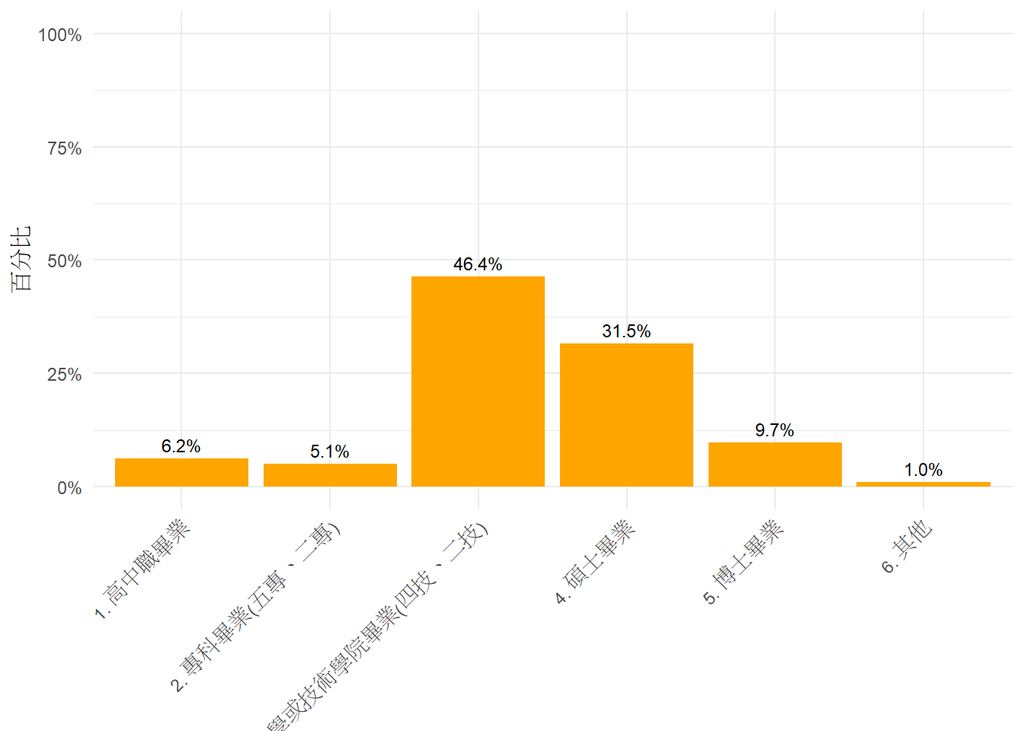

### 性別角色態度_家庭中大部分重要的事情應當要由男人來決定 (樣本數=4231)

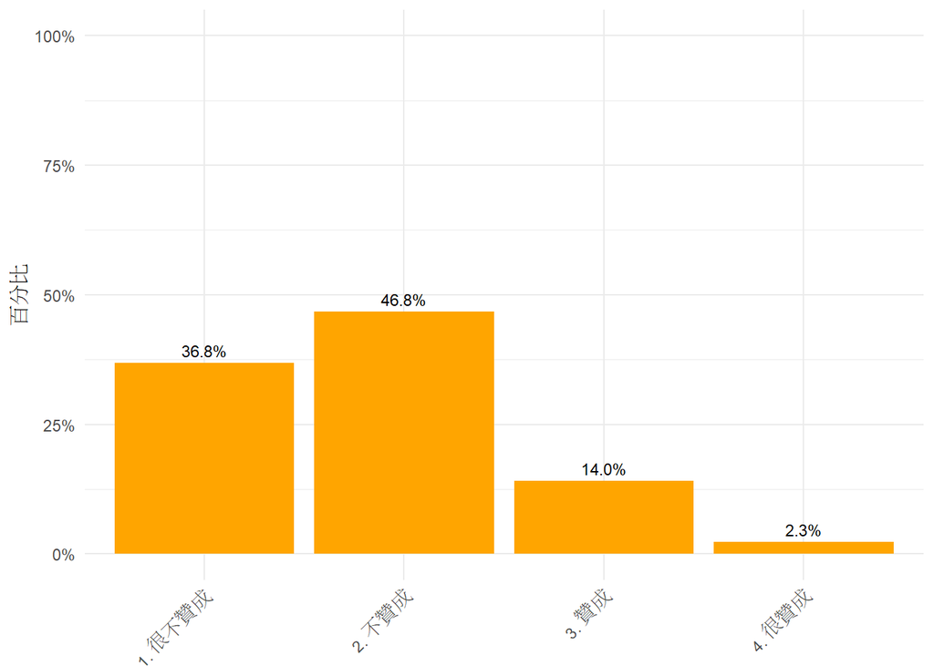

### 性別角色態度_當母親有工作時，學齡前子女比較容易受到不好的影響 (樣本數=4218)

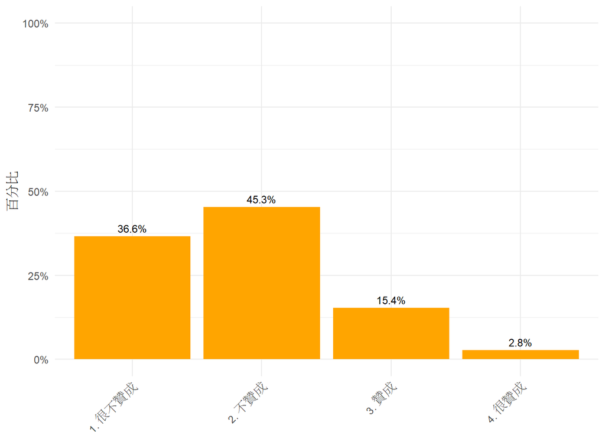

### 性別角色態度_丈夫的責任就是賺錢養家，妻子的責任就是照顧家庭 (樣本數=4235)

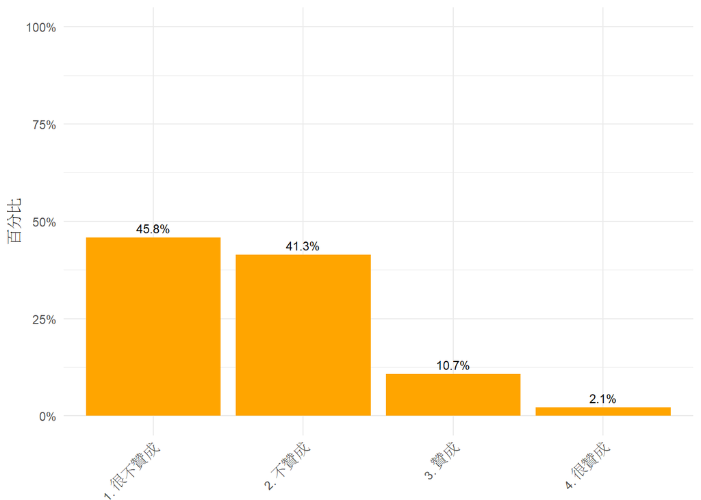

### 性別角色態度_經濟不景氣需裁員時，應該先從（已婚）女性員工裁起 (樣本數=4235)

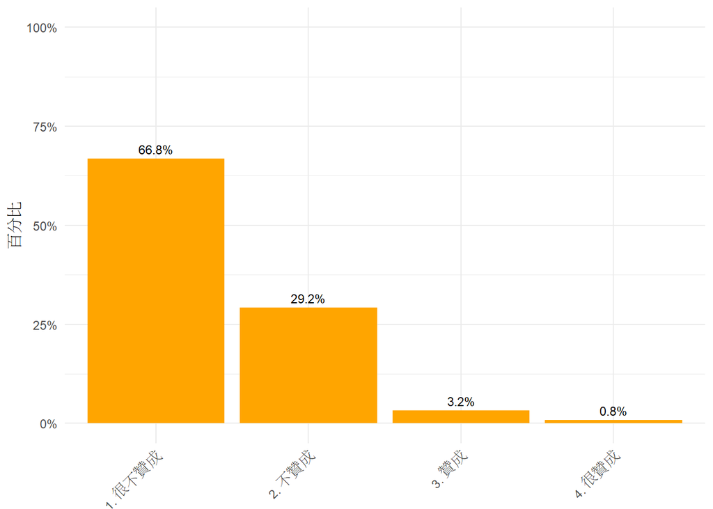

### 性別角色態度_一般說來，男性比女性更適合當主管 (樣本數=4235)

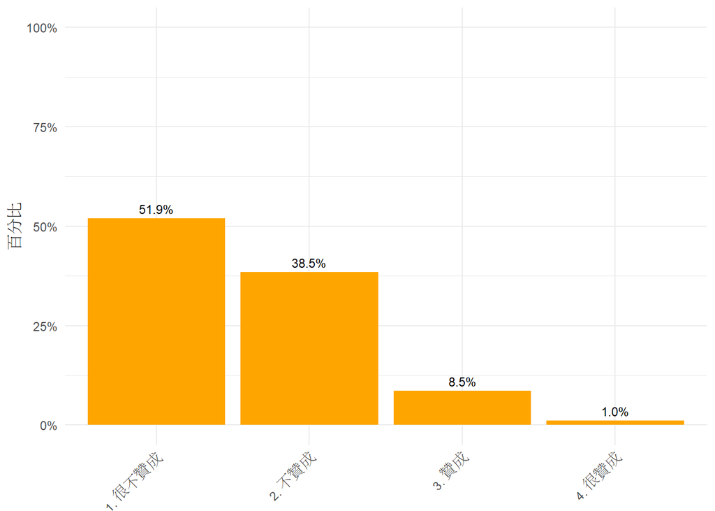

### 性別角色態度_在一個家庭中，先生和太太都工作是很自然的事 (樣本數=4235)

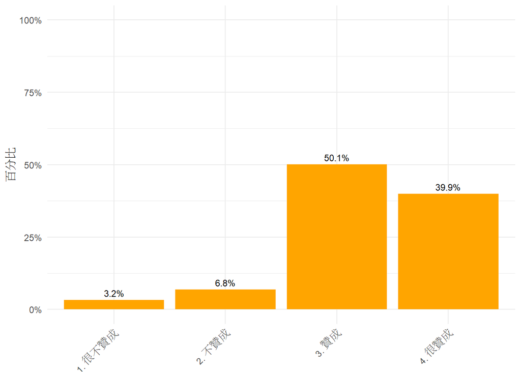

### 性別角色態度_在結婚之後，太太如果想要繼續工作，先生應該支持 (樣本數=4235)

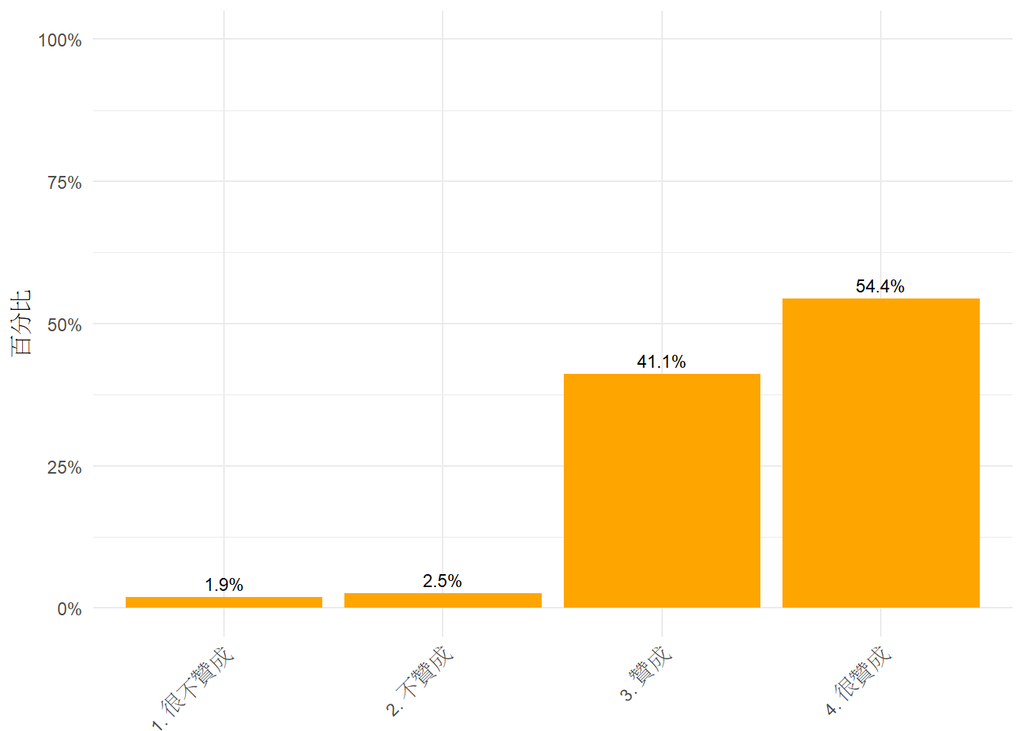

### 性別角色態度_夫妻有小孩之後，先生賺的錢如果足夠養家，太太就應該留在家中照顧小孩 (樣本數=4235)

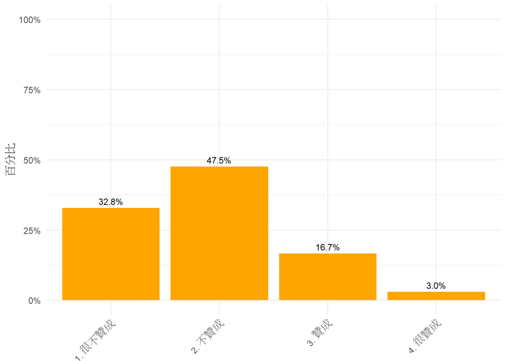

### 性別角色態度_夫妻有小孩之後，如果兩個人都有工作，先生應該花與太太同樣多的時間照顧小孩 (樣本數=4235)

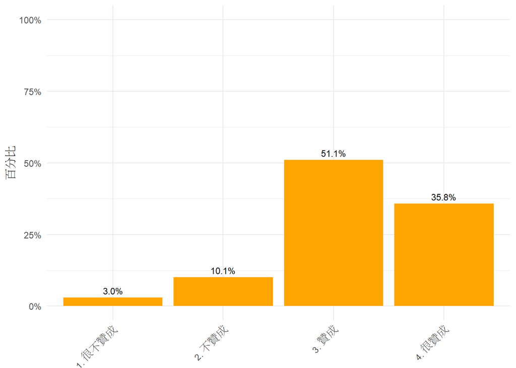

### 性別角色態度_在工作與家庭發生衝突時，太太應該以家庭為優先選擇 (樣本數=4235)

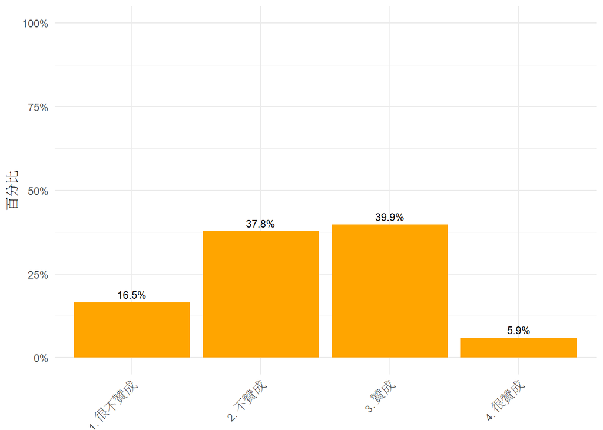

### 性別角色態度_婚姻應該由一男一女不同性別組成 (樣本數=4235)

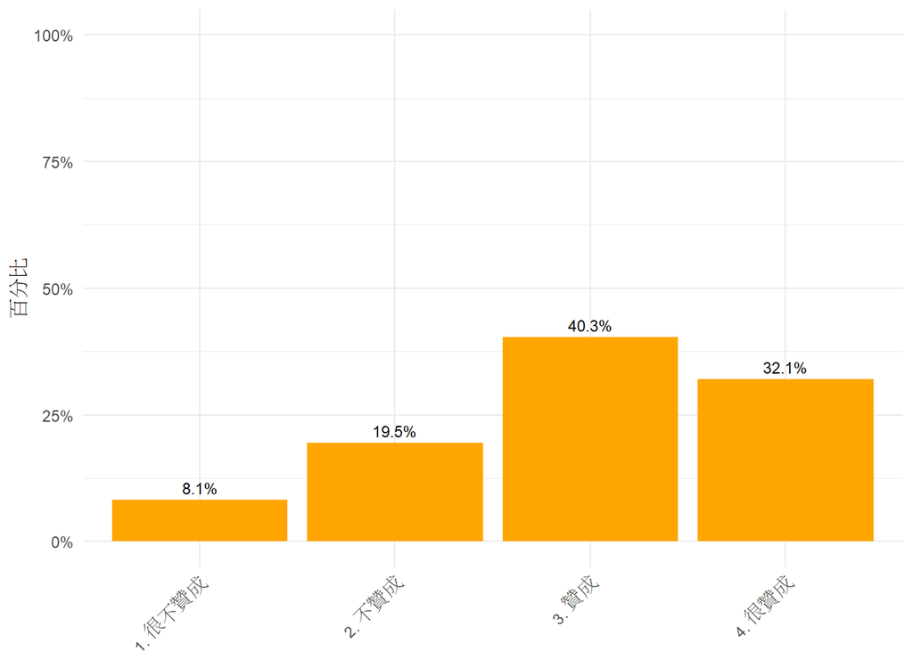

### 孝道信念_子女對父母的養育之恩心存感激 (樣本數=4226)

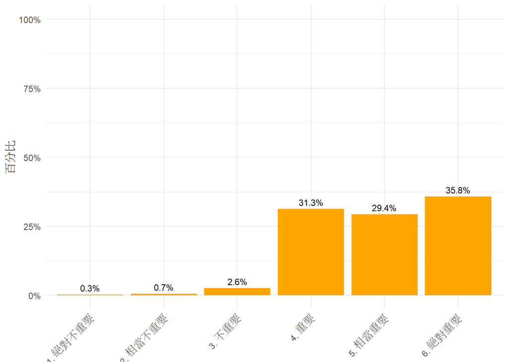

### 孝道信念_無論父母交代什麼事，都立刻去做 (樣本數=4226)

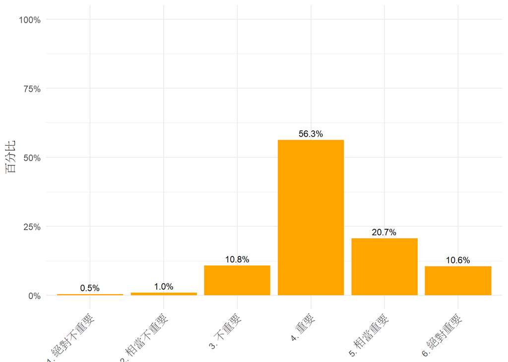

### 孝道信念_放棄個人的志向，達成父母的心願 (樣本數=4226)

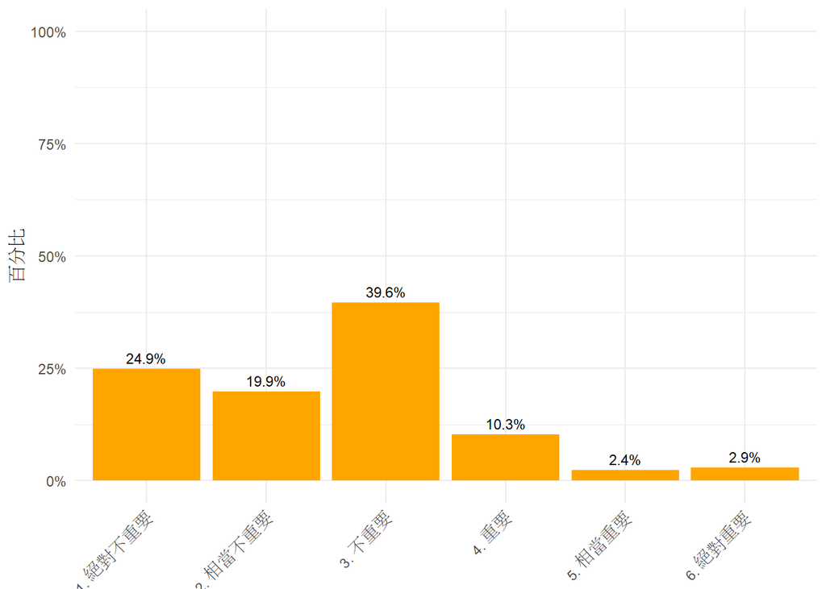

### 孝道信念_父母忙碌時，主動幫助父母 (樣本數=4226)

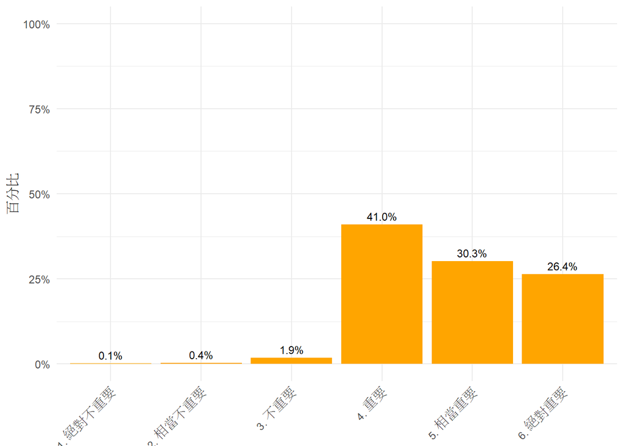

### 孝道信念_奉養父母，使父母生活更為舒適 (樣本數=4226)

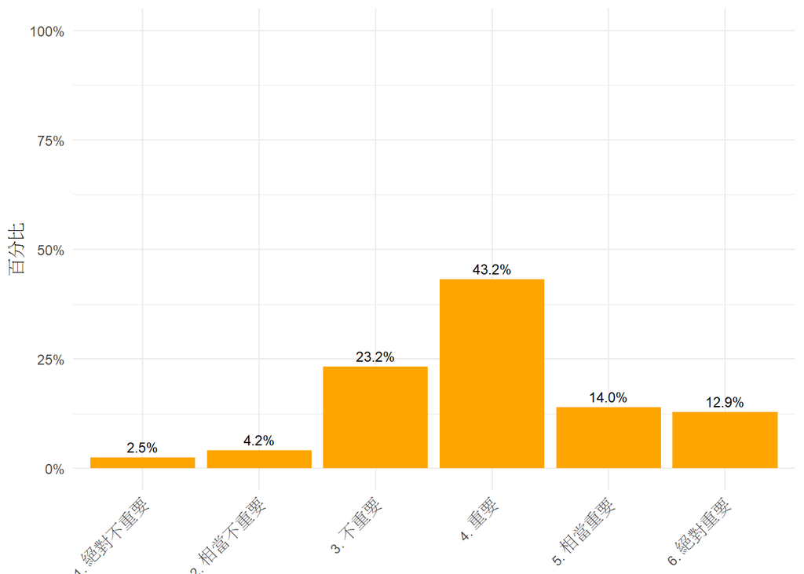

### 孝道信念_與父母意見不合時，要順從父母的意見 (樣本數=4226)

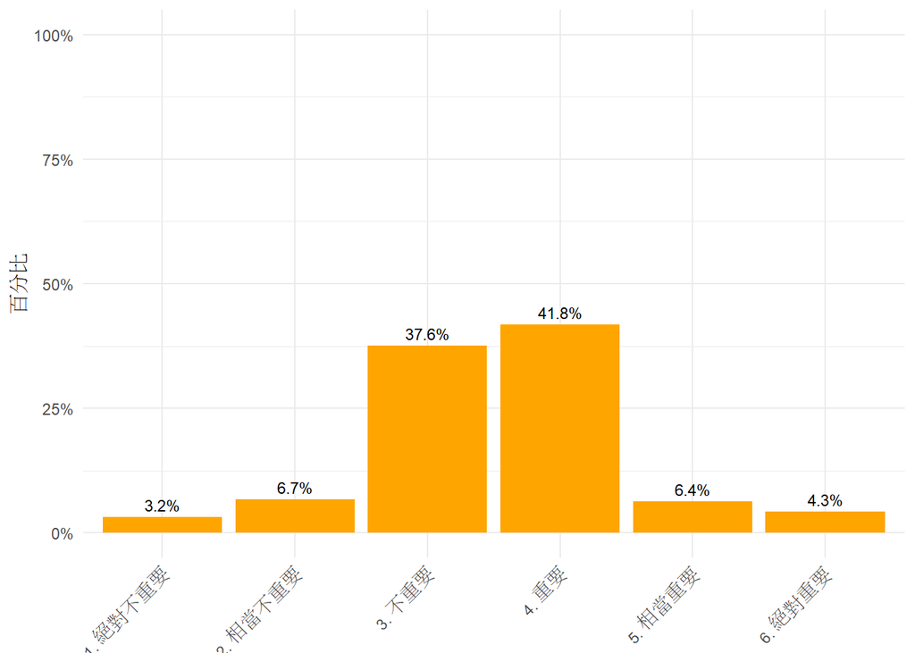

### 大五人格_您不太愛講話 (樣本數=4212)

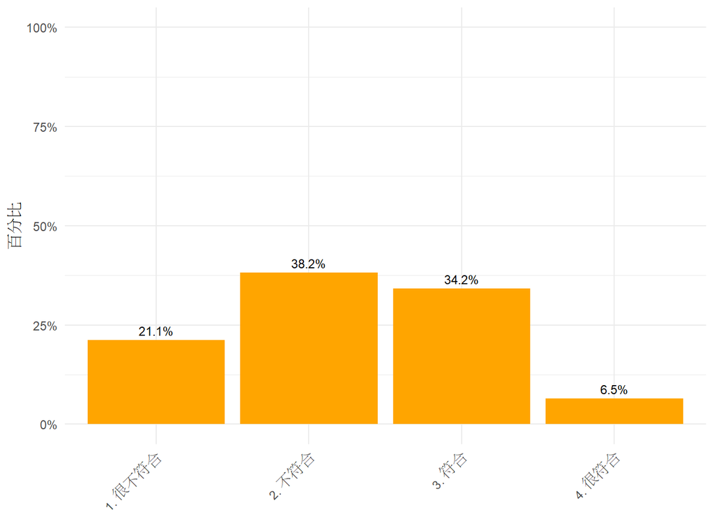

### 大五人格_您很有同情心 (樣本數=4216)

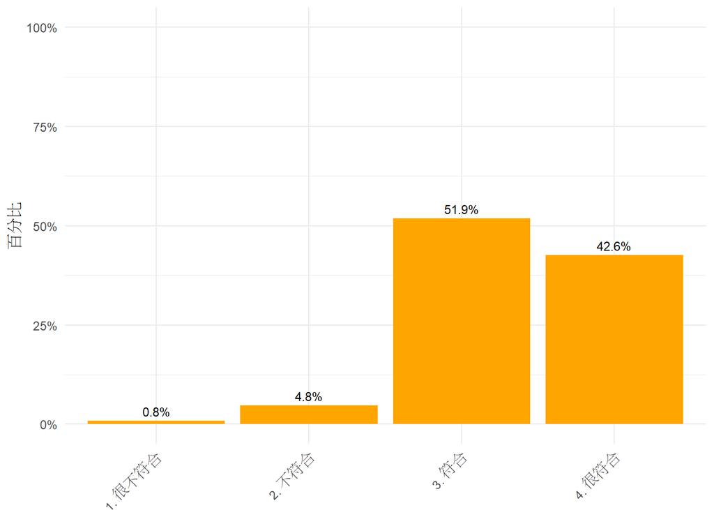

### 大五人格_您事情做到完為止 (樣本數=4219)

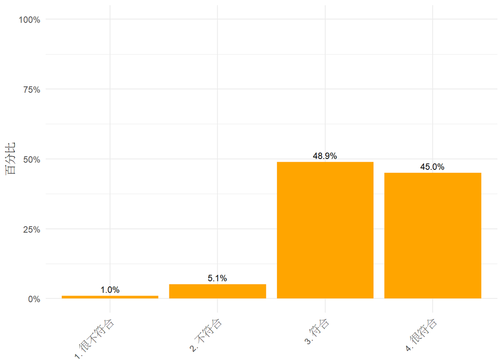

### 大五人格_您懂得放鬆而且會處理壓力 (樣本數=4219)

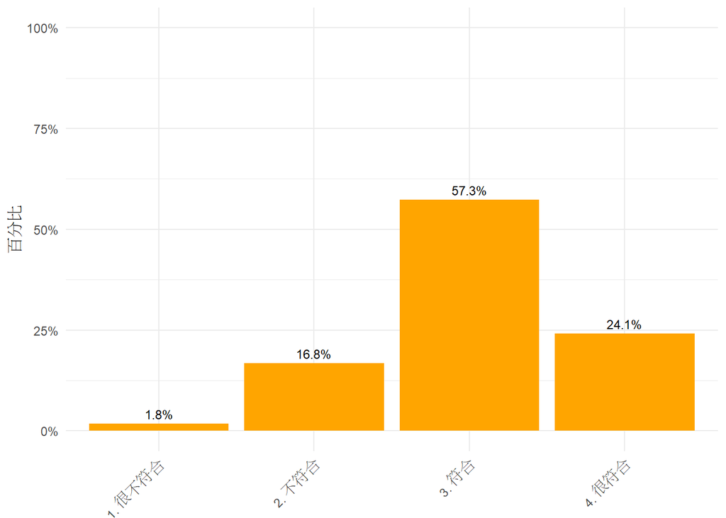

### 大五人格_您對多花腦筋思考的事物很有興趣 (樣本數=4218)

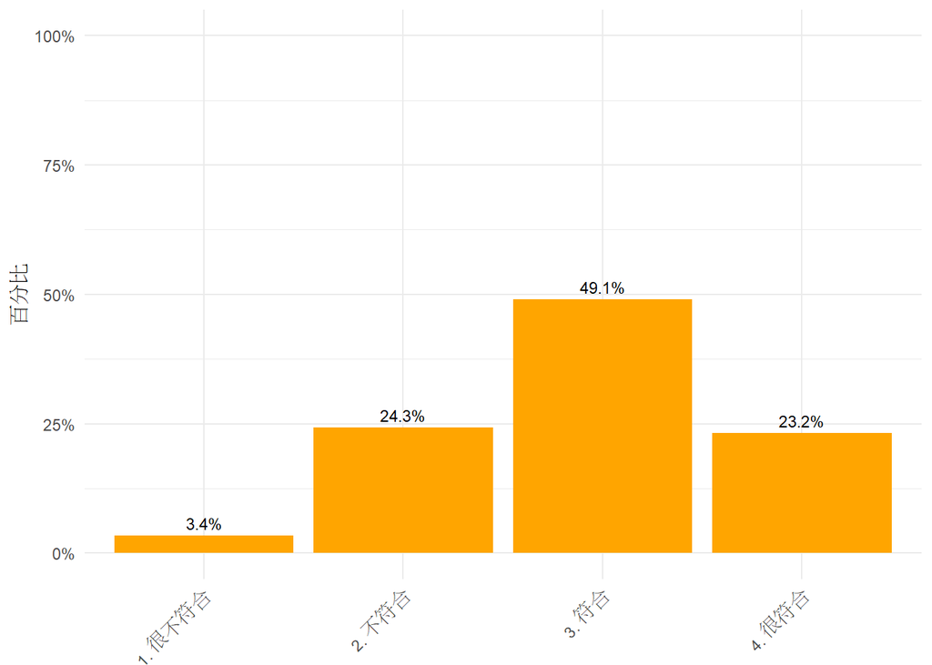

### 大五人格_您外向，會和人交際 (樣本數=4219)

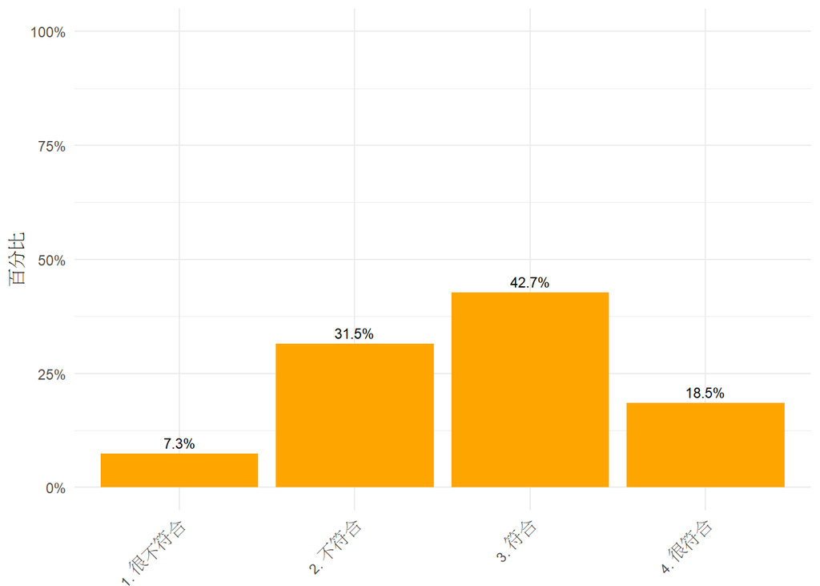

### 大五人格_您比較會挑別人毛病 (樣本數=4218)

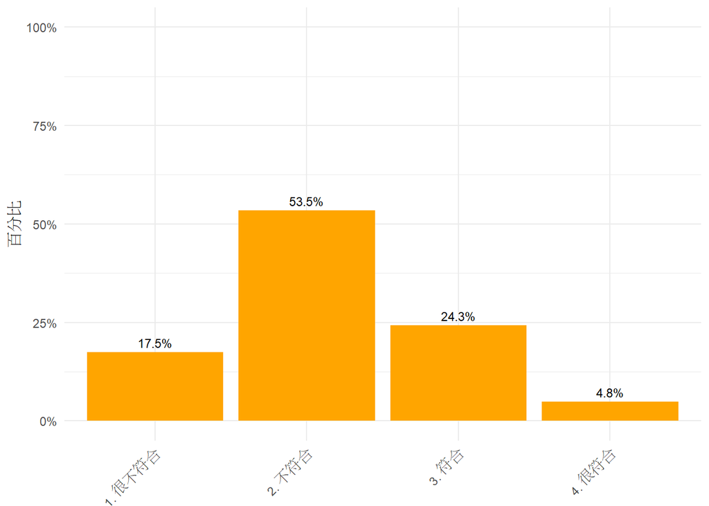

### 大五人格_您粗心大意 (樣本數=4219)

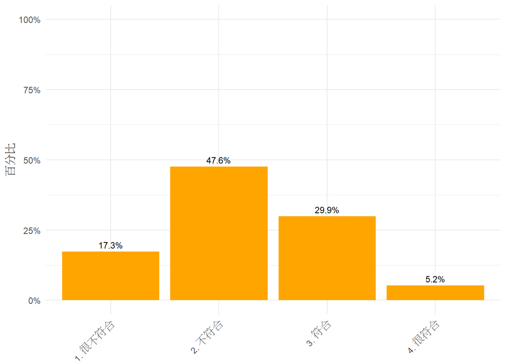

### 大五人格_您容易緊張 (樣本數=4219)

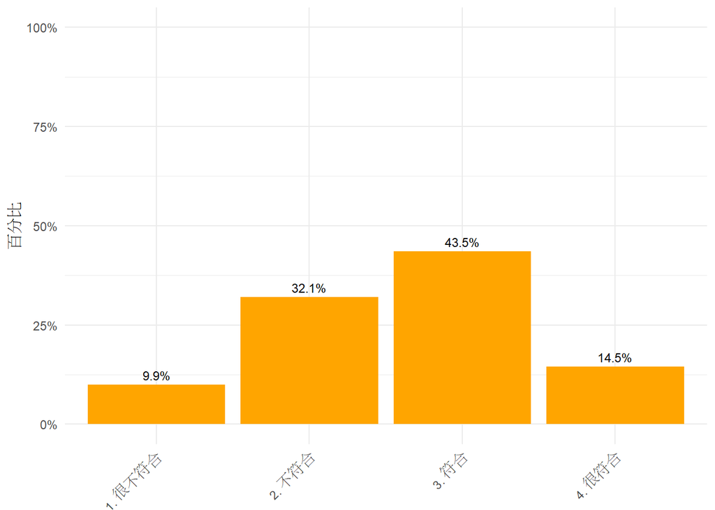

### 大五人格_ 您對新奇的事物比較沒興趣 (樣本數=4219)

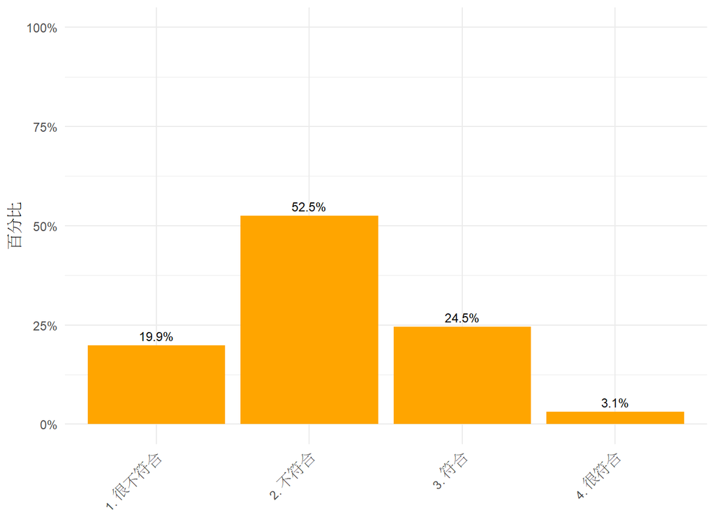

### 自我價值_我沒有辦法解決自己的某些問題 (樣本數=4199)

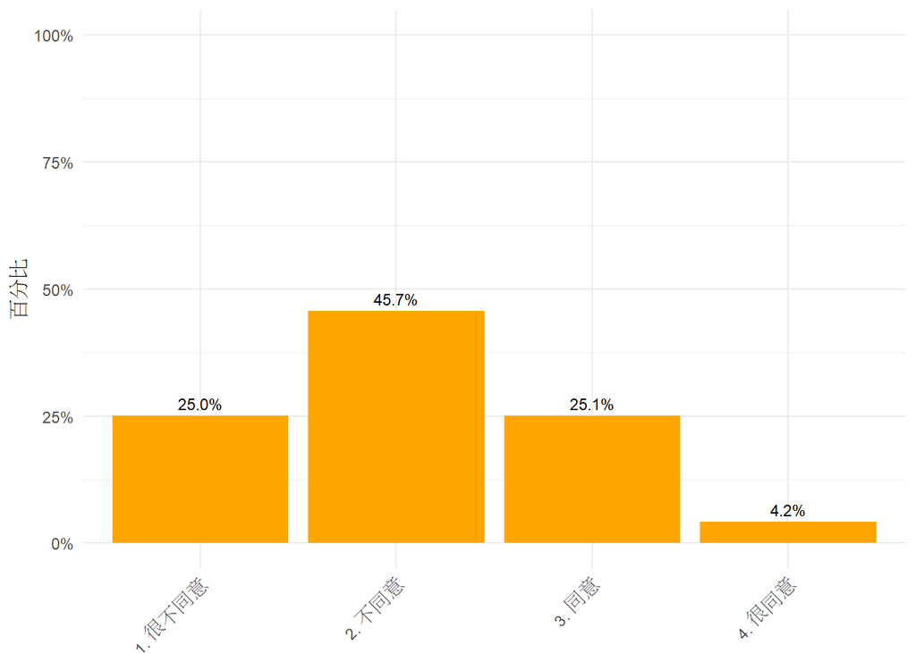

### 自我價值_我沒有辦法控制發生在我身上的事 (樣本數=4199)

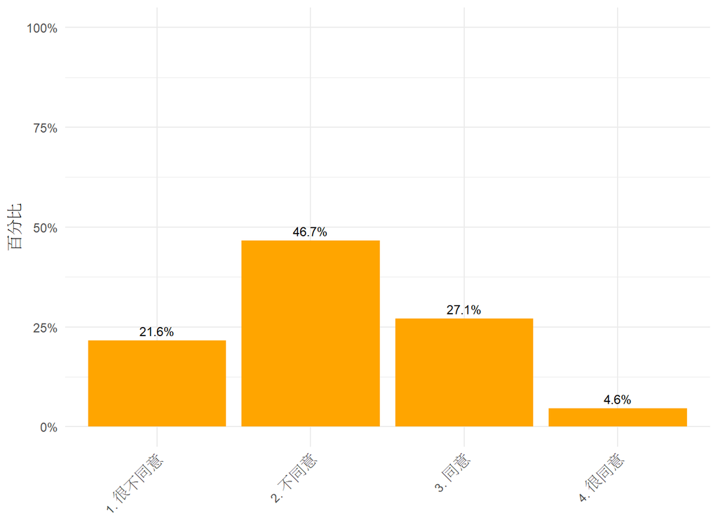

### 自我價值_要處理生活上的種種問題，讓我感到很無力 (樣本數=4199)

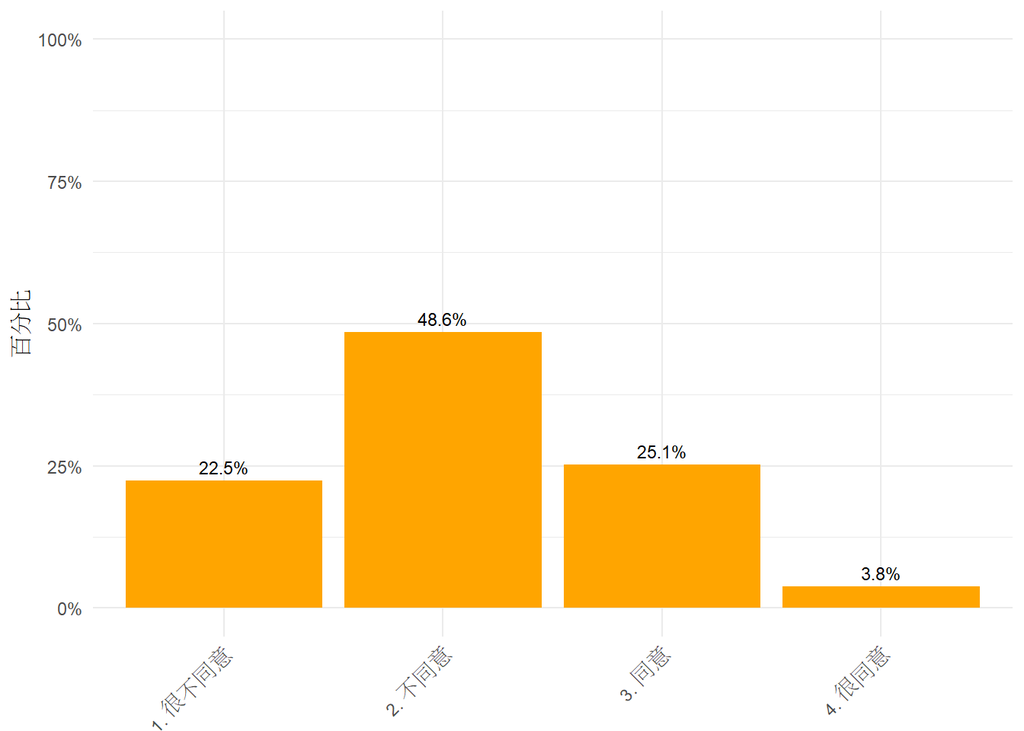